# Homework 10

Sarah Morris

4/14/2021

#### Question 1: Using a for loop, write a function to calculate the number of zeroes in numeric vector. Before entering the loop set up a counter variable & inside the loop, add 1 to the counter each time you have a zero in the matrix.

```r
# ------------------------------------------------------
# FUNCTION Counting_Zeros
# description: counts the number of zeros in a vector
# inputs: numeric vector
# outputs: count of zeros
########################################################
Counting_Zeros <- function(x = 0:50) {
  counter <- 0

  for(i in seq_along(x)){
    if(x[i] == 0){
      counter <- counter + 1
    }
  }
  return(counter)

} # end of Counting_Zeros
# ------------------------------------------------------
Counting_Zeros()
```

```
## [1] 1
```

```r
# it works
# testing with another vector input
vector <- rep(-1:1,50)
Counting_Zeros(vector)
```

```
## [1] 50
```

```r
# still works
```

#### Question 2: write function using subseting into a single line of code

```r
# using same vector created for question 1
length(which(vector == 0))
```

```
## [1] 50
```

```r
# yea this is far simpler than the function
```

#### Question 3: write a function that takes 2 integers that represent the rows & columns in a matrix & outputs a new matrix that is the product of the row number and the column number

```r
# ------------------------------------------------------
# FUNCTION matrix_multiplyer
# description: creates a matrix and fills it w/ row # * col #
# inputs: number of rows & number of columns
# outputs: matrix
########################################################
matrix_multiplyer <- function(x=5, y=6) {

  mymatrix <- matrix(data=0, nrow=x, ncol=y)
  for(i in 1:x){
    for(j in 1:y){
      mymatrix[i,j] = i*j
    }
  }

  return(mymatrix)

} # end of matrix_multiplyer
# ------------------------------------------------------
matrix_multiplyer()
```

```
##      [,1] [,2] [,3] [,4] [,5] [,6]
## [1,]    1    2    3    4    5    6
## [2,]    2    4    6    8   10   12
## [3,]    3    6    9   12   15   18
## [4,]    4    8   12   16   20   24
## [5,]    5   10   15   20   25   30
```

#### Question 4: conduct a randomization test for some of my own data

modify:  
- read in data function  
- calculate the metric function  
- randomize the data function

```r
library(ggplot2)
library(TeachingDemos)

char2seed("chocolate withdrawal")

# ------------------------------------------------------
# FUNCTION read_data
# description: read in (or generate) data set for analysis
# inputs: file name (or nothing)
# outputs: 3 column dataframe of observed data (ID,x,y)
########################################################
read_data <- function(z=NULL) {
  if(is.null(z)){
    x_obs <- 1:20
    y_obs <- x_obs + 10*rnorm(20)
    df <- data.frame(ID=seq_along(x_obs),x_obs, y_obs)
    } else

  df <- read.csv(file=z, header=TRUE, stringsAsFactors = FALSE, sep=",")
  return(df)

} # end of read_data
# ------------------------------------------------------

# ------------------------------------------------------
# FUNCTION get_metric
# description: calculate metric for randomization test
# inputs: 2 column dataframe for regression
# outputs: regression slope
########################################################
get_metric <- function(z=NULL) {
  if(is.null(z)){
    x_obs <- 1:20
    y_obs <- x_obs + 10*rnorm(20)
    z <- data.frame(x_obs, y_obs)}

  . <- lm(z[,2]~z[,1])
  . <- summary(.)
  . <- .$coefficients[2,1]

  slope <- .
  return(slope)

} # end of get_metric
# ------------------------------------------------------

# ------------------------------------------------------
# FUNCTION shuffle_data
# description: randomize data for regression analysis
# inputs: 3-column data frame (ID,xVar,yVar)
# outputs: 3-column data frame (ID,xVar,yVar)
########################################################
shuffle_data <- function(z=NULL) {
  if(is.null(z)){
    x_obs <- 1:20
    y_obs <- x_obs + 10*rnorm(20)
    z <- data.frame(x_obs, y_obs)}

  z[,2] <- sample(z[,2]) # reshuffle density column

  return(z)

} # end of shuffle_data
# ------------------------------------------------------

# ------------------------------------------------------
# FUNCTION get_pval
# description: calculate p value from simulation
# inputs: list of observed metric, and vector of simulated metrics
# outputs: lower, upper tail probability values
########################################################
get_pval <- function(z=NULL) {
  if(is.null(z)){
    z <- list(rnorm(1),rnorm(1000)) }
  p_lower <- mean(z[[2]]<=z[[1]])
  # what proportion of 1000 cases in which simulated value is less than the observed value (lower tail probability)
  p_upper <- mean(z[[2]]>=z[[1]]) # double bracket pulls out item from list
  # what proportion of 1000 simulated slopes are greater than the observed slope
  # z[1] = observed slope & z[2] = 1000 simulated slopes
  return(c(pL=p_lower,pU=p_upper)) # these have to sum to 1
  # we have values above and below; area under curve = 1
} # end of get_pval
# ------------------------------------------------------

# ------------------------------------------------------
# FUNCTION plot_ran_test
# description: create ggplot of histogram of simulated values
# inputs: list of observed metric and vector of simulated metrics
# outputs: saved ggplot graph
########################################################
plot_ran_test <- function(z=NULL) {
  if(is.null(z)){
    z <- list (rnorm(1), rnorm(1000))}

  df <- data.frame(ID=seq_along(z[[2]]),sim_x=z[[2]])
  p1 <- ggplot(data=df, mapping=aes(x=sim_x))
  p1 + geom_histogram(mapping=aes(fill=I("goldenrod"), color=I("black")))+
    geom_vline(aes(xintercept=z[[1]],col="blue")) # vertical line for obs slope
  # tail probabilities are the left and right of the line
  # histogram is the distribution of 1000 simulated slopes

} # end of plot_ran_test
# ------------------------------------------------------

########################################################################
#### PUTTING IT ALL TOGETHER ###########################################
########################################################################

# Preliminaries
n_sim <- 1000 # number of simulated data sets
x_sim <- rep(NA, n_sim) # set up empty vector for simulated slopes


df <- read_data(z="leaf_data.csv") # read in the data
x_obs <- get_metric(df) # get slope of observed data

for (i in seq_len(n_sim)) {
  x_sim[i] <- get_metric(shuffle_data(df)) # run simulation
}

slopes <- list(x_obs,x_sim)
get_pval(slopes)
```

```
##    pL    pU
## 0.002 0.998
```

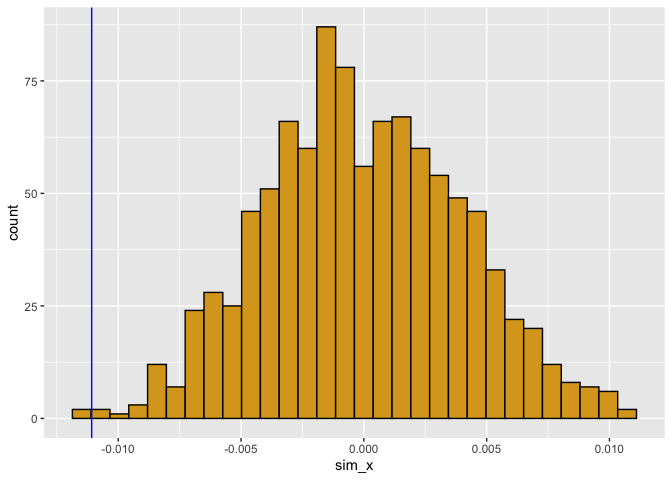

```r
# pL = 0.002
# pU = 0.998
# observed slope is smaller than most of the simulated

plot_ran_test(slopes)
```

```r
# blue line splits distribution into upper and lower tail
# observed slope is unusually small compared to simulated distribution
```